# DWEI5_Aula03_HTML-TagsBasicas_CSS-PropriedadesFontesTextos

[figure not shown]

Instituto Federal de São Paulo (IFSP)  
[Campus Bragança Paulista/SP](https://bra.ifsp.edu.br)  
**Análise e Desenvolvimento de Sistemas (ADS)**  
**5o. módulo**  
**Profa. Ana Paula Müller Giancoli**  
paulagiancoli@ifsp.edu.br

[figure not shown]

## AULA 03 - HTML: TAGS DE LISTAS E PROPRIEDADES CSS DE FONTES E TEXTOS

### Agenda

- Unidades de Medidas
- Família de Fontes
- Propriedades CSS de Fontes
- Propriedades CSS de Textos
- Tags HTML de Listas
- Propriedades CSS de Listas
- Propriedades CSS de Backgroud
- Perguntas

### 1. Unidades de Medidas

### 1.1. Relativas

| Unidade | Descrição |
| --- | --- |
| em* | Relativo ao tamanho da fonte do elemento. |
| ex | Relativo ao x-height da fonte corrente (raro usar). |
| ch | Relativo a width de 0. |
| rem* | Relativo ao tamanho da fonte do elemento root. |
| vw | Relativo a 1% do width do viewport. |
| vh | Relativo a 1% da height do viewport. |
| vmin | Relativo a 1% da dimensão menor do viewport. |
| vmax | Relativo a 1% da dimensão maior do viewport. |
| % | Percentual. |
|  | **viewport = tamanho da janela do navegador** |
|  | **se viewport = 50cm wide, 1vw = 0.5cm.** |

### 1.2. Absolutas

| Unidade | Descrição | Equivalência |
| --- | --- | --- |
| cm | Centímetros. |  |
| mm | Milímetros. |  |
| in | Polegadas. | 1in = 96px = 2.54cm |
| px | Pixels. | 1px = 1/96in |
| pt | Pontos. | 1pt = 1/72in |
|  | **valor padrão dos navegadores = 16px** |  |
|  | **1em = 100% = 16px** |  |

### 2. Família de Fontes

- Para conhecer mais sobre a história do CSS, consulte [History](https://www.w3.org/Style/CSS20/history.html).
- Para conhecer mais sobre web fontes, consulte [History Web Fonts](https://thehistoryoftheweb.com/web-fonts/).

### 2.1. Fontes

- Pesquisas indicam que para uma boa leitura dos sites, cada linha de texto *deve conter entre 45 a 90 caracteres*. A quantidade de caracteres depende da família de fonte utilizada.
- **O padrão é 65 caracteres**.
- **Sugestões**:
  - para dispositivos pequenos, utilizar o **tamanho da fonte: 16px**, **altura mínima linha: 1.2em**. Ou,
  - utilizar o **tamanho da fonte: 18px**, **altura mínima linha: 1.2em**.

### 2.1.1. Propriedade font-family

- Permite formatar a família de fontes.

```
tag ou classe ou id {
    propriedade: valor;
}

/* Exemplo */
#ft1 {
    font-family: sans-serif;
}
```

- No arquivo de estilo, a propriedade **font-family**: Indica o nome da fonte a ser utilizada. Poderá indicar diversas fontes, separadas por vírgula.
  - Caso o navegador não encontre a fonte desejada, utiliza o default do micro.
  - Se o nome for composto, deve ser declarado entre aspas duplas.

### 2.1.2. Fontes genéricas

- Valores para as famílias de fontes genéricas são:
  - Serif
  - Sans-serif
  - Monospace
  - Cursive
  - Fantasy

**Arquivo: index.html**

```
<!--Arquivo index.html-->
<!DOCTYPE html>
<html lang="pt-br">
<head>
  <meta charset="UTF-8">
  <title>Aula03</title>
  <link rel="stylesheet" href="css/estilo.css">
</head>
<body>
  <h1> IFSP - Bragança Paulista  </h1>
  <h1 id="ft1"> A fonte utilizada neste título foi Serif.</h1>
  <h1 id="ft2"> A fonte utilizada neste título foi Sans-Serif.</h1>
  <h1 id="ft3"> A fonte utilizada neste título foi Monospace.</h1>
  <h1 id="ft4"> A fonte utilizada neste título foi Cursive.</h1>
  <h1 id="ft5"> A fonte utilizada neste título foi Fantasy.</h1>
</body>
</html>
```

**Arquivo: estilo.css**

```
/* Arquivo estilo.css dentro da pasta css. */
#ft1 {
  font-family: serif;
}
#ft2 {
  font-family: sans-serif;
}
#ft3 {
  font-family: monospace;
}
#ft4 {
  font-family: cursive;
}
#ft5 {
  font-family: fantasy;
}
```

**Saída:**

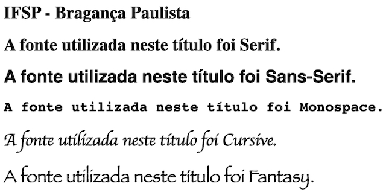

### 2.1.3. Fontes WebFonts

- IE aceita somente extensão EOT. Demais aceitam TTF e OTF. **São fontes com direitos autorais, pagas**:

  ```
  font-family: indica o nome da família de fontes a ser utilizada.
  src: url(''): indica o local onde a fonte foi armazenada com a sua extensão.
  ```

**Observação**:

- Para escolher uma fonte e testar, acesse: [Font Squirrel](https://www.fontsquirrel.com/fonts/list/popular).
- Para ler mais a respeito, consulte [Propriedade @font-face CSS – Fonts externas na web](https://tableless.com.br/font-face-fonts-externas-na-web/).

**Arquivo: index.html**

```
<!--Arquivo index.html-->
<!DOCTYPE html>
<html lang="pt-br">
<head>
    <meta charset="UTF-8">
    <title>Aula03</title>
    <link rel="stylesheet" href="css/estilo.css">
</head>
<body>
  <h1> IFSP - Bragança Paulista  </h1>
  <h1 id="ft1"> A fonte utilizada neste título foi Serif.</h1>
  <h1 id="ft2"> A fonte utilizada neste título foi Sans-Serif.</h1>
  <h1 id="ft3"> A fonte utilizada neste título foi Monospace.</h1>
  <h1 id="ft4"> A fonte utilizada neste título foi Cursive.</h1>
  <h1 id="ft5"> A fonte utilizada neste título foi Fantasy.</h1>
  <h1 id="ft6"> A fonte utilizada neste título foi uma WebFont (Pacifico - SIL Open Font License).</h1>
</body>
</html>
```

**Arquivo: estilo.css**

```
/* Arquivo estilo.css dentro da pasta css. */
#ft1 {
  font-family: serif;
}
#ft2 {
  font-family: sans-serif;
}
#ft3 {
  font-family: monospace;
}
#ft4 {
  font-family: cursive;
}
#ft5 {
  font-family: fantasy;
}
@font-face {
  font-family: Pacifico;
  src: url(../fontes/pacifico/Pacifico.ttf);
}
#ft6 {
  font-family: Pacifico;
}
```

**Saída:**

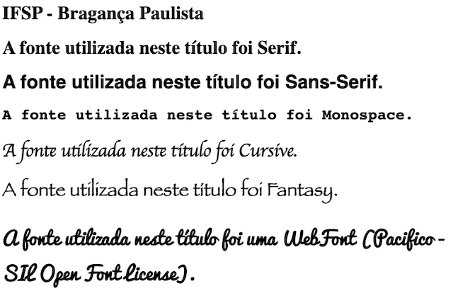

### 2.1.4. Google Fontes

- Para utilizar as fontes do google, acesse o link [Fontes do Google](https://fonts.google.com), escolha a fonte a utilizar e insira no seu arquivo html o link para a fonte, e no seu arquivo css, a regra de formatação da fonte.

**Arquivo: index.html**

```
<!--Arquivo index.html-->
<!DOCTYPE html>
<html lang="pt-br">
<head>
    <meta charset="UTF-8">
    <title>Aula03</title>
    <link href="https://fonts.googleapis.com/css2?family=Modak&display=swap" rel="stylesheet">
    <link rel="stylesheet" href="css/estilo.css">
</head>
<body>
  <h1> IFSP - Bragança Paulista  </h1>
  <h1 id="ft1"> A fonte utilizada neste título foi Serif.</h1>
  <h1 id="ft2"> A fonte utilizada neste título foi Sans-Serif.</h1>
  <h1 id="ft3"> A fonte utilizada neste título foi Monospace.</h1>
  <h1 id="ft4"> A fonte utilizada neste título foi Cursive.</h1>
  <h1 id="ft5"> A fonte utilizada neste título foi Fantasy.</h1>
  <h1 id="ft6"> A fonte utilizada neste título foi uma WebFont (Pacifico - SIL Open Font License).</h1>
  <h1 id="ft7"> A fonte utilizada neste título foi uma Fonte do Google.</h1>
</body>
</html>
```

**Arquivo: estilo.css**

```
/* Arquivo estilo.css dentro da pasta css. */
#ft1 {
  font-family: serif;
}
#ft2 {
  font-family: sans-serif;
}
#ft3 {
  font-family: monospace;
}
#ft4 {
  font-family: cursive;
}
#ft5 {
  font-family: fantasy;
}
@font-face {
  font-family: Pacifico;
  src: url(../fontes/pacifico/Pacifico.ttf);
}
#ft6 {
  font-family: Pacifico;
}
#ft7 {
  font-family: 'Modak', cursive;
}
```

**Saída:**

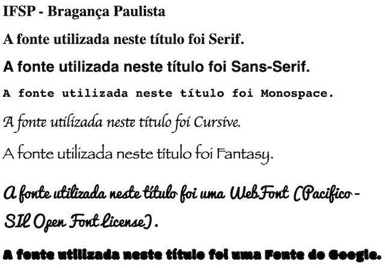

### 3. Propriedades CCS de Fontes

### 3.1. Propriedade font-size

- Permite formatar o tamanho da fonte.
- Valores possíveis: pixel, percentage, xx-small, x-small, small, smaller medium, large, x-large, xx-large, larger.
- **Exemplo**: Formatando o tamanho da fonte dos parágrafos com 16px.

  ```
  p {
    font-size: 16px;
  }
  ```

### 3.2. Propriedade font-size-adjust

- Permite formatar a altura das letras minúsculas em relação as maiúsculas.
- Valores possíveis: valor numérico múltiplo do tamanho da fonte. Utilize o valor none para não formatar este item.
- No exemplo, as letras menores serão exibidas na altura de 8px. (= 16px / 2)
- **Exemplo**:

  ```
  p {
    font-size: 16px;
    font-size-adjust: .5;
  }
  ```

### 3.3. Propriedade font-style

- Permite formatar o estilo da fonte.
- Valores possíveis: normal, italic, oblique.
- Algumas famílias de fontes não reconhecem o valor italic, logo, utilize oblique.
- **Exemplo**:

  ```
  p {
    font-style: italic;
  }
  ```

### 3.4. Propriedade font-weight

- Permite formatar o negrito da fonte.
- Valores possíveis: normal, bold.
- **Exemplo**:

  ```
  p {
    font-weight: bold;
  }
  ```

### 3.5. Propriedade font-variant

- Permite formatar as letras minúsculas em maiúsculas, em tamanho menor.
- Valores possíveis: normal, small-caps.
- **Exemplo**:

  ```
  p {
    font-variant: small-caps;
  }
  ```

### 3.6. Propriedade line-height

- Permite formatar a altura de linha.
- Valores possíveis: utilizar um múltiplo do tamanho da fonte, px, em, %. Dê preferência para **em**.
- **Exemplo**: se utilizar 2em, equivale a espaçamento duplo.

  ```
  p {
    line-height: 2em;
  }
  ```

### 3.7. Propriedade font

- Permite formatar a fonte de uma única vez.
- Valores possíveis: verificar cada uma das propriedades que são opcionais. O valor da altura de linha: line-height poderá ser em em, %, px.
- **Exemplo**:
  - Ordem para declarar valores da propriedade font: font-style font-variant font-weight font-size/ line-height font-family;
  - Os valores para as propriedades de font-size e de font-family são obrigatórios.

```
p {
    font: italic bold small-caps 3em/.9 ’Title Font’, Constantia, Georgia, Times, ‘Times New Roman’ ;

}
```

```
p {
    font-size: 16px;
    font-size-adjust: .5;
    font-style: italic;
    font-weight: bold;
    font-variant: small-caps;
    line-height: 2em;
}
```

### 4. Propriedades CCS de Textos

- Para aprofundamento, consulte [MDN Web Docs](https://developer.mozilla.org/en-US/docs/Learn/CSS/Styling_text/Fundamentals).

### 4.1. Propriedade color

- Permite formatar a cor do texto.
- Valores possíveis: rgb, rgba, hexadecimal, hsl. Verificar aula anterior, caso tenha alguma dúvida.
- Cada uma das cores RGB variam de 0 a 255.
- **Exemplo**:

  ```
  p {
    color: rgb(245, 34, 9);
  }
  ```

### 4.2. Propriedade text-align

- Permite formatar o alinhamento horizontal do texto.
- Valores possíveis: right, left, center, justify.
- **Exemplo**:

  ```
  p {
    text-align: right;
  }
  ```

### 4.3. Propriedade text-transform

- Permite formatar como o texto será visualizado.
- Valores possíveis: none, capitalize, uppercase, lowercase.
- **Exemplo**:

  ```
  p {
    text-transform: capitalize;
  }
  ```

### 4.4. Propriedade text-decoration

- Permite formatar o subescrito do texto.
- Valores possíveis: none, overline, line-through, underline.
- **Exemplo**:

  ```
  p {
    text-decoration: none;
  }
  ```

### 4.5. Propriedade text-indent

- Permite formatar a indentação da primeira linha do texto.
- Valores possíveis: px, em, %.
- **Exemplo**:

  ```
  p {
    text-indent: 10px;
  }
  ```

### 4.6. Propriedade text-direction

- Permite formatar a direção do texto.
- Valores possíveis: ltr (valor default), rtl, initial, inherit.
- **Exemplo**:

  ```
  p {
    text-direction: rtl;
  }
  ```

### 4.7. Propriedade text-shadow

- Permite formatar a sombra do texto. Blur = borrão. Se for 0px, a sombra será sólida.
- Valores possíveis: none, initial, inherit.
- Sintaxe:

```
tag ou classe ou id {
    text-shadow: h-shadow v-shadow blur color;
}
```

- **Exemplo1**: Valores h-shadow e v-shadow positivos (direita, abaixo).

```
p {
    text-shadow: +10px +10px +3px blue;
}
```

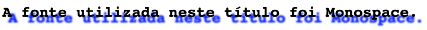

- **Exemplo2**: Valores h-shadow positivo e v-shadow negativo (direita, acima).

  ```
  p {
    text-shadow: +10px -10px +3px blue;
  }
  ```

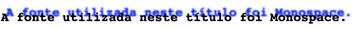

- **Exemplo3**: Valores h-shadow e v-shadow negativos (esquerda, acima).

  ```
  p {
    text-shadow: -10px -10px +3px blue;
  }
  ```

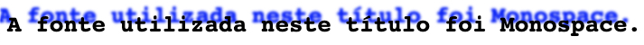

- **Exemplo4**: Valores h-shadow negativo e v-shadow positivo (esquerda, abaixo).

  ```
  p {
    text-shadow: -10px +10px +3px blue;
  }
  ```

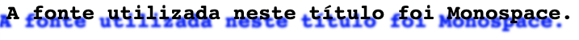

### 4.8. Propriedade letter-spacing

- Permite formatar o espaçamento entre letras.
- Valores possíveis: normal, px, em, %.
- O tamanho pode ser em pixel, em, e se negativo, aproxima as letras. Dê preferência para **em**.
- **Exemplo**:

  ```
  p {
    letter-spacing: 2em;
  }
  ```

### 4.9. Propriedade word-spacing

- Permite formatar o espaçamento entre palavras.
- Valores possíveis: normal, px, em, %.
- O tamanho pode ser em pixel, em, e se negativo, aproxima as palavras. Dê preferência para **em**.
- **Exemplo**:

  ```
  p {
    word-spacing: 2em;
  }
  ```

### 4.10. Propriedade vertical-align

- Permite formatar o alinhamento vertical do texto. Funciona somente com elementos inline, inline-block, table-cells.
- Valores possíveis: baseline (valor default), px, em, %, initial, inherit, sub, super, top, text-top, middle, bottom, text-bottom.
- **Exemplo**:

  ```
  p {
    vertical-align: middle;
  }
  ```

### 4.11. Propriedade white-spacing

- Permite formatar o alinhamento vertical do texto.
- Valores possíveis:
  - normal (valor default),
  - nowrap (mais de um espaço é compactado em um só, não quebra linha),
  - pre (espaço é preservado pelo navegador, quebra se tiver br),
  - pre-line (mais de um espaço é compactado em um só),
  - pre-wrap (espaço é preservado pelo navegador),
  - initial,
  - inherit.
- **Exemplo**:

  ```
  p {
    white-spacing: pre-line;
  }
  ```

### 5. Tags HTML de Listas

- Para aprofundamento, consulte [MDN Web Docs](https://developer.mozilla.org/pt-BR/docs/Aprender/HTML/Introducao_ao_HTML/Fundamentos_textuais_HTML).
- De acordo com [MDN Web Docs], "as listas estão em toda parte na vida — desde sua lista de compras à lista de instruções que você seguiu inconscientemente para chegar à sua casa todos os dias, para as listas das instruções que está seguindo nesses tutoriais! As listas também estão na Web e temos três tipos diferentes para prestarmos atenção".
  - Listas não ordenadas.
  - Listas ordenadas.
  - Lista de definições.

### 5.1. Listas não ordenadas

- As listas não ordenadas são usadas para marcar listas de itens para os quais a ordem dos itens não importa.
  - Utilizamos as tags HTML **< ul > e </ ul >** para abertura e fechamento da lista.
  - E para os itens da lista, utilizamos as tags HTML **< li > e </ li >**.

**Arquivo: index.html**

```
<!--Arquivo index.html-->
<!DOCTYPE html>
<html lang="pt-br">
<head>
    <meta charset="UTF-8">
    <title>Aula03</title>
    <link rel="stylesheet" href="css/estilo.css">
</head>
<body>
  <h1> IFSP - Bragança Paulista  </h1>
  <h2>Lista não ordenada</h2>
      <ul>Comprar
        <li>Limão.</li>
        <li>Manga.</li>
        <li>Pêssego.</li>
        <li>Maçã.</li>
      </ul>
</body>
</html>
```

**Saída:**

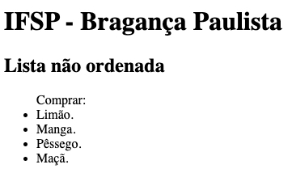

### 5.2. Listas ordenadas

- As listas ordenadas são usadas para marcar listas de itens para os quais a ordem dos itens importa.
  - Utilizamos as tags HTML **< ol > e </ ol >** para abertura e fechamento da lista.
  - E para os itens da lista, utilizamos as tags HTML **< li > e </ li >**.

**Arquivo: index.html**

```
<!--Arquivo index.html-->
<!DOCTYPE html>
<html lang="pt-br">
<head>
    <meta charset="UTF-8">
    <title>Aula03</title>
    <link rel="stylesheet" href="css/estilo.css">
</head>
<body>
  <h1> IFSP - Bragança Paulista  </h1>
  <h2>Lista ordenada</h2>
      <ol>Organizar nesta ordem
        <li>Planos de Ensino.</li>
        <li>Planos de Aula.</li>
        <li>Planos de Atividades.</li>
        <li>Diários.</li>
      </ol>
</body>
</html>
```

**Saída:**

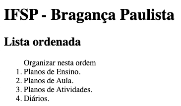

### 5.3. Listas de definição

- Para aprofundamento, consulte [MDN Web Docs](https://developer.mozilla.org/pt-BR/docs/Web/HTML/Element/dl).
- Engloba uma lista de pares de termos e descrições. Um uso comum para este elemento é para implementar um glossário ou exibir metadados(uma lista de pares chave e valor).
  - Utilizamos as tags HTML **< dl > e </ dl >** para abertura e fechamento da lista de definição.
  - Para os termos, títulos, cabeçalhos das listas, utilizamos as tags HTML **< dt > e </ dt>**.
  - Representa os itens da lista, a definição dos termos listados imediantamente antes deste pelas outras tags, utilizamos as tags HTML **< dd > e </ dd >**.

**Arquivo: index.html**

```
<!--Arquivo index.html-->
<!DOCTYPE html>
<html lang="pt-br">
<head>
    <meta charset="UTF-8">
    <title>Aula03</title>
    <link rel="stylesheet" href="css/estilo.css">
</head>
<body>
  <h1> IFSP - Bragança Paulista  </h1>
  <h2>Lista de Definição</h2>
      <dl>
        <dt>DWEI5</dt>
        <dt>Disciplina de Desenvolvimento Web</dt>
        <dt>5o. módulo</dt>
          <dd>A disciplina aborda os conceitos de linguagem de marcação de hipertexto, formatação de estilos e linguagem de script. </dd>
      </dl>
</body>
</html>
```

**Saída:**

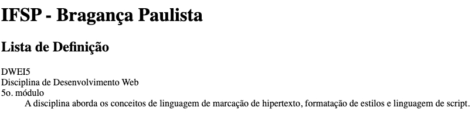

### 6. Propriedades CSS de Listas

### 6.1. Propriedade list-style-type

- Para aprofundamento, consulte [MDN Web Docs](https://developer.mozilla.org/en-US/docs/Web/CSS/list-style-type).
- O atributo type define o estilo de marcador para a lista.
- Valores: circle, disc, square, decimal, decimal-leading- zero, upper-roman, lower-roman, upper-alpha, lower- alpha, lower-greek ou none.
- **Exemplo**:

  ```
  ul {
    list-style-type: circle;
  }
  ```

### 6.2. Propriedade list-style-image

- Para aprofundamento, consulte [MDN Web Docs](https://developer.mozilla.org/en-US/docs/Web/CSS/list-style-image).
- O atributo image: este atributo define uma imagem a ser usada como marcador de um item da lista.
- Valores: url(< caminho da imagem >);.
- **Exemplo**:

  ```
  ul {
    list-style-image: url("../../img/elefante.jpg");
  }
  ```

### 6.3. Propriedade list-style-position

- Para aprofundamento, consulte [MDN Web Docs](https://developer.mozilla.org/en-US/docs/Web/CSS/list-style-position).
- O atributo position define a posição relativa do item na lista.
- Valores: inside (alinhada à esquerda) ou outside (indentado).
- **Exemplo**:

  ```
  ul {
    list-style-position: inside;
  }
  ```

### 6.4. Propriedade list-style

- Para aprofundamento, consulte [MDN Web Docs](https://developer.mozilla.org/en-US/docs/Web/CSS/list-style).
- **Sintaxe**:

  ```
  ul {
    list-style: list-style-type list-style-image list-style-position;
  }
  ```

- **Exemplo**:

  ```
  ul {
    list-style: circle url("../../img/elefante.jpg") inside;
  }
  ```

### 7. Propriedades CSS de Background

- Para formatarmos o fundo das imagens, itens, utilizamos a propriedade css de background.
- A propriedade background permite controlar o plano de fundo de qualquer elemento. Também, é uma propriedade abreviada, similar ao list-style. Em uma única linha configuramos todo o background.
- Para maiores conhecimentos, consulte [Background](https://css-tricks.com/almanac/properties/b/background/).
- E para exemplos de padrões de background, consulte [CSS3 Patterns Gallery](https://leaverou.github.io/css3patterns/).

```
body {
    background:
        url(imagens/elefante.jpg) /* image */
        top center / 200px 200px  /* position / size */
        no-repeat                 /* repeat */
        fixed                     /* attachment */
        padding-box               /* origin */
        content-box               /* clip */
        red;                      /* color */
}
```

### 7.1. Propriedades

- **background-image**: define uma imagem de fundo;
- **background-position**: define como e onde a imagem de fundo é posicionada;
- **background-size**: define as dimensões da imagem no box;
- **background-repeat**: define a maneira como a imagem de fundo é posicionada;
- **background-attachment**: define se a imagem de fundo "rola" ou não com a tela;
- **background-origin**: define a posição de origem da imagem no box;
- **background-clip**: define a área do box onde a imagem de fundo é aplicada;
- **background-color**: define a cor do fundo;

### 7.1.1. Valores Possíveis para cada propriedade

#### background-image

- URL: url(caminho/imagem.gif).
- URL: url(’caminho/imagem.gif’).
- URL: url("caminho/imagem.gif").
- Gradiente linear: linear-gradient(45deg, blue, red).
- Gradiente radial: radial-gradient(20px 50px, green, blue, red).

#### background-position

- Xpx Ypx
- X% Y%
- top left
- top center
- top right
- center left
- center center
- center right
- bottom left
- bottom center
- bottom right
- top
- right
- bottom
- left

#### background-size

- 150px 70px: a imagem terá as dimensões definidas por unidade de medida CSS.
- auto: a imagem terá suas dimensões originais - este é o valor padrão.
- contain: a imagem terá as dimensões de modo a que sua maior dimensão ocupe toda a extensão do box e a menor dimensão seja tal que o aspect ratio (relação entre largura e altura) seja preservado.
- cover: a imagem terá as dimensões de modo a que sua menor dimensão ocupe toda a extensão do box e a maior dimensão seja tal que o aspect ratio (relação entre largura e altura) seja preservado.

#### background-repeat

- imagem não repete: no-repeat.
- imagem repete na vertical e horizontal: repeat.
- imagem repete na vertical: repeat-y.
- imagem repete na horizontal: repeat-x.
- imagem toca as quatro bordas internas do box e são espaçadas de modo a se distribuirem igualmente: space.
- imagem toca as quatro bordas internas do box e são redimensionadas de modo a preencherem o fundo tocando umas nas outras: round.

#### background-attachment

- fixed: imagem permanece fixa em relação à viewport (janela do navegador) e não rola juntamente com o conteúdo.
- scroll: imagem não permanece fixa em relação à viewport (janela do navegador) e rola juntamente com o conteúdo - este é o valor padrão.
- local: imagem permanece fixa em relação à viewport (janela do navegador) mas quando aplicada ao box de um elemento rola juntamente com o conteúdo se o elemento tiver um mecanismo de rolagem definido por overflow: scroll.

#### background-origin

- border-box: a a imagem tem por origem o canto superior esquerdo do box considerada das bordas do box, se houver uma - este é o comportamento padrão.
- padding-box: a imagem tem por origem o canto superior esquerdo do box sem considerar as bordas do box, se houver uma.
- ontent-box: a imagem tem por origem o canto superior esquerdo do box sem considerar o padding e as bordas do box, se houver.

#### background-clip

- border-box: a imagem ocupa até a área das bordas do box, inclusive, se houver uma - este é o comportamento padrão.
- padding-box: a imagem ocupa até a área de padding do box, inclusive, se houver uma e não ocupa a área de bordas.
- content-box: a imagem ocupa até a área de conteúdo do boxe não ocupa as áreas de padding e bordas se houver.

#### background-color

- código hexadecimal: #ffc6d9.
- código rgb: rgb(255,235,0).
- código rgba: rgb(255,235,0, 0.7).
- código hsl: hsl(210,100%,40%).
- código hsla: hsla(155,80%,35%,0.4).
- palavra-chave: red, blue, green...etc.
- transparente: transparent.
- O CSS3 adicionou suporte para vários fundos, que se sobrepõem. Qualquer propriedade relacionada a planos de fundo pode ter uma lista separada por vírgula, assim:

  ```
  body {
    background: url(elefante.jpg), url(casa.jpg) black;
    background-repeat: repeat-x, no-repeat;
  }
  ```

- Cada valor na lista separada por vírgula corresponde a uma camada: o primeiro valor é a camada superior, o segundo valor é a segunda camada e a cor do plano de fundo é sempre a última camada.

### Referências

- Esta aula foi elaborada a partir do conteúdo disponibilizado em cada um dos links indicados no próprio texto.

### Perguntas

- Esclareça suas eventuais dúvidas durante as aulas.
- Ou pelo *E-mail*: paulagiancoli@ifsp.edu.br.
- Ou pelo *Fórum* do componente curricular.

*ADS - HTML5, CSS3, JS - 5o. módulo*.  
Modelo e formato elaborado por profa. Ana Paula Müller Giancoli - BSD 2-Clause License. - Julho.2021.